# Project: Explorative Data Analysis -- The TMDb movie database

- Introduction
- Data Wrangling
- Exploratory Data Analysis
- Conclusions

## Introduction

The TMDb movie database gathers data about movies released between 1960 and 2015.

This analysis proposes to dig through the TMDb movie database and will try to establish dependencies and independencies across the different dataset variables.

The dataset can be downloaded [here](https://d17h27t6h515a5.cloudfront.net/topher/2017/October/59dd1c4c_tmdb-movies/tmdb-movies.csv).

### Some Questions

Along the analysis, we will try to unveil certain characteristics of the dataset and address several questions, including:

- Is there a general trend in terms of revenues, budgets and profits?
- Which genres stand out in terms of profits?
- Does duration (runtime) skew to certain genres and does it influence profits?
- What are the most successful months in terms of profits?
- Are there properties associated with profits overall?

```python
# importing libraries and setting up the notebook

import numpy as np
import pandas as pd
import seaborn as sns
import matplotlib.pyplot as plt
import missingno as msno
import warnings
warnings.simplefilter(action='ignore')
%matplotlib inline
```

## Data Wrangling

### General Properties

```python
df = pd.read_csv('tmdb-movies.csv')
df.shape
```

```
(10866, 21)
```

```python
df.dtypes
```

```
id                        int64
imdb_id                  object
popularity              float64
budget                    int64
revenue                   int64
original_title           object
cast                     object
homepage                 object
director                 object
tagline                  object
keywords                 object
overview                 object
runtime                   int64
genres                   object
production_companies     object
release_date             object
vote_count                int64
vote_average            float64
release_year              int64
budget_adj              float64
revenue_adj             float64
dtype: object
```

```python
df.head()
```

|  | id | imdb_id | popularity | budget | revenue | original_title | cast | homepage | director | tagline | ... | overview | runtime | genres | production_companies | release_date | vote_count | vote_average | release_year | budget_adj | revenue_adj |
| --- | --- | --- | --- | --- | --- | --- | --- | --- | --- | --- | --- | --- | --- | --- | --- | --- | --- | --- | --- | --- | --- |
| 0 | 135397 | tt0369610 | 32.985763 | 150000000 | 1513528810 | Jurassic World | Chris Pratt\|Bryce Dallas Howard\|Irrfan Khan\|Vi... | http://www.jurassicworld.com/ | Colin Trevorrow | The park is open. | ... | Twenty-two years after the events of Jurassic ... | 124 | Action\|Adventure\|Science Fiction\|Thriller | Universal Studios\|Amblin Entertainment\|Legenda... | 6/9/15 | 5562 | 6.5 | 2015 | 1.379999e+08 | 1.392446e+09 |
| 1 | 76341 | tt1392190 | 28.419936 | 150000000 | 378436354 | Mad Max: Fury Road | Tom Hardy\|Charlize Theron\|Hugh Keays-Byrne\|Nic... | http://www.madmaxmovie.com/ | George Miller | What a Lovely Day. | ... | An apocalyptic story set in the furthest reach... | 120 | Action\|Adventure\|Science Fiction\|Thriller | Village Roadshow Pictures\|Kennedy Miller Produ... | 5/13/15 | 6185 | 7.1 | 2015 | 1.379999e+08 | 3.481613e+08 |
| 2 | 262500 | tt2908446 | 13.112507 | 110000000 | 295238201 | Insurgent | Shailene Woodley\|Theo James\|Kate Winslet\|Ansel... | http://www.thedivergentseries.movie/#insurgent | Robert Schwentke | One Choice Can Destroy You | ... | Beatrice Prior must confront her inner demons ... | 119 | Adventure\|Science Fiction\|Thriller | Summit Entertainment\|Mandeville Films\|Red Wago... | 3/18/15 | 2480 | 6.3 | 2015 | 1.012000e+08 | 2.716190e+08 |
| 3 | 140607 | tt2488496 | 11.173104 | 200000000 | 2068178225 | Star Wars: The Force Awakens | Harrison Ford\|Mark Hamill\|Carrie Fisher\|Adam D... | http://www.starwars.com/films/star-wars-episod... | J.J. Abrams | Every generation has a story. | ... | Thirty years after defeating the Galactic Empi... | 136 | Action\|Adventure\|Science Fiction\|Fantasy | Lucasfilm\|Truenorth Productions\|Bad Robot | 12/15/15 | 5292 | 7.5 | 2015 | 1.839999e+08 | 1.902723e+09 |
| 4 | 168259 | tt2820852 | 9.335014 | 190000000 | 1506249360 | Furious 7 | Vin Diesel\|Paul Walker\|Jason Statham\|Michelle ... | http://www.furious7.com/ | James Wan | Vengeance Hits Home | ... | Deckard Shaw seeks revenge against Dominic Tor... | 137 | Action\|Crime\|Thriller | Universal Pictures\|Original Film\|Media Rights ... | 4/1/15 | 2947 | 7.3 | 2015 | 1.747999e+08 | 1.385749e+09 |

5 rows × 21 columns

```python
# Exploring span of years comprised in the dataset
df['release_year'].min()
```

```
1960
```

```python
df['release_year'].max()
```

```
2015
```

### Data Cleaning

> As this analysis will focus on measurable outcomes, a first view of the entire dataset shows that some columns can be dropped, namely:
> - 'popularity', 'vote_count', 'vote_average', 'homepage', 'tagline', 'keywords' and 'overview' because they are biased data.
> - 'budget' and 'revenue' because it will be more accurate to use the adjusted 'budget_adj' and 'revenue_adj' columns.
> - 'release_year' because it will be more accurate to use the 'release_date' column instead.

10 columns will be dropped, 11 will remain.

> Additionally, the strategy for the other columns will be as follows:
- 'id', 'imdb_id': first, locate missing / null cells, second, count duplicates.
- 'cast', 'genres', 'production_companies', 'director': first, locate missing cells, second, find methodology for filling na cells. As needed, split into columns using the '|' separator.
- convert 'release_date' object type to datetime type.
- check for how many zero values are in 'budget_adj' and 'revenue_adj' as these might weigh on some statistics.

```python
# Dropping selected columns.
df.drop(['popularity', 'vote_count', 'keywords', 'vote_average', 'budget', 'revenue', 'homepage', 'tagline', 'overview', 'release_year'], axis=1, inplace=True)
```

```python
# Checking selected columns were dropped.
# Note that we're keeping both 'id' and 'imdb_id' columns in order to check for possible duplicates in each one of them.
df.info()
```

```
<class 'pandas.core.frame.DataFrame'>
RangeIndex: 10866 entries, 0 to 10865
Data columns (total 11 columns):
id                      10866 non-null int64
imdb_id                 10856 non-null object
original_title          10866 non-null object
cast                    10790 non-null object
director                10822 non-null object
runtime                 10866 non-null int64
genres                  10843 non-null object
production_companies    9836 non-null object
release_date            10866 non-null object
budget_adj              10866 non-null float64
revenue_adj             10866 non-null float64
dtypes: float64(2), int64(2), object(7)
memory usage: 933.9+ KB
```

```python
# Checking for empty / NaN cells across entire dataframe.
null_columns = df.columns[df.isnull().any()]
df[null_columns].isnull().sum()
```

```
imdb_id                   10
cast                      76
director                  44
genres                    23
production_companies    1030
dtype: int64
```

> The **missingno package** allows to visualize the completeness of the dataset.

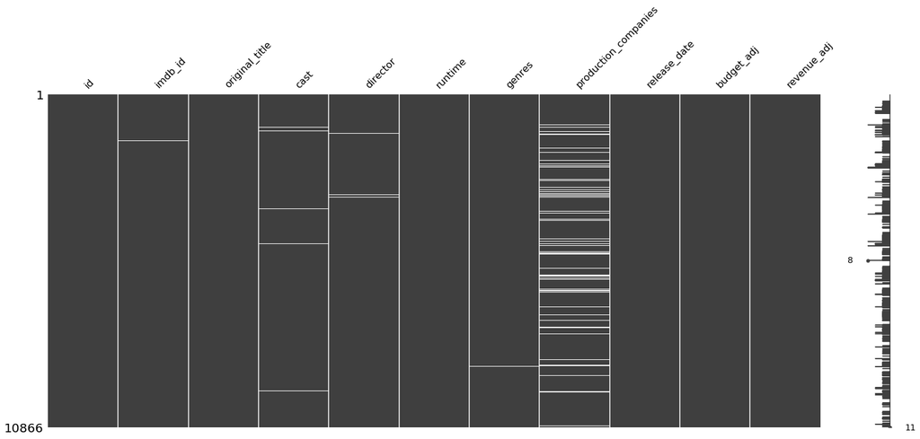

```python
# We can use the 'missingno' visualization package to see if the set is complete or having a lot of empty / NaN values.
df_missingno = df.replace("nan", np.nan)
msno.matrix(df)
```

> The dataset shows it is fairly complete apart from the 'production_companies' column.

```python
# Checking for columns that include zeros, this is especially important for budget_adj and revenue_adj.
df[df == 0].count(axis=0)
```

```
id                         0
imdb_id                    0
original_title             0
cast                       0
director                   0
runtime                   31
genres                     0
production_companies       0
release_date               0
budget_adj              5696
revenue_adj             6016
dtype: int64
```

> The **sum of zeros in budget_adj and revenue_adj columns is impacting the dataset significantly**. As a result, we shall drop the rows with zeros in those columns when it comes to making statistics based on budget and revenue.

```python
# Checking for 'id' row data based on the missing 'imdb_id' cells.
## The result shows the analysis for these rows can be made using solely the 'id' column.
df[df['imdb_id'].isnull()]
```

|  | id | imdb_id | original_title | cast | director | runtime | genres | production_companies | release_date | budget_adj | revenue_adj |
| --- | --- | --- | --- | --- | --- | --- | --- | --- | --- | --- | --- |
| 548 | 355131 | NaN | Sense8: Creating the World | Tuppence Middleton\|Bae Doona \|Brian J. Smith\|A... | NaN | 25 | Documentary\|Science Fiction | Netflix | 8/10/15 | 0.000000 | 0.0 |
| 997 | 287663 | NaN | Star Wars Rebels: Spark of Rebellion | Freddie Prinze Jr.\|Vanessa Marshall\|Steve Blum... | Steward Lee\|Steven G. Lee | 44 | NaN | NaN | 10/3/14 | 0.000000 | 0.0 |
| 1528 | 15257 | NaN | Hulk vs. Wolverine | Fred Tatasciore\|Bryce Johnson\|Steve Blum\|Nolan... | Frank Paur | 38 | Animation\|Action\|Science Fiction | Marvel Studios | 1/27/09 | 0.000000 | 0.0 |
| 1750 | 101907 | NaN | Hulk vs. Thor | Graham McTavish\|Fred Tatasciore\|Matthew Wolf\|J... | Sam Liu | 41 | Action\|Animation\|Fantasy\|Science Fiction | Marvel Studios | 1/27/09 | 0.000000 | 0.0 |
| 2401 | 45644 | NaN | Opeth: In Live Concert At The Royal Albert Hall | Mikael Åkerfeldt\|Martin "Axe" Axenrot\|Martin ... | NaN | 163 | Music | NaN | 9/21/10 | 0.000000 | 0.0 |
| 4797 | 369145 | NaN | Doctor Who: The Snowmen | Matt Smith\|Jenna Coleman\|Richard E. Grant\|Ian ... | NaN | 60 | NaN | BBC Television UK | 12/25/12 | 0.000000 | 0.0 |
| 4872 | 269177 | NaN | Party Bercy | Florence Foresti | NaN | 120 | Comedy | TF1 Vidéo | 9/23/12 | 0.000000 | 0.0 |
| 6071 | 279954 | NaN | Portal: Survive! | Monique Blanchard\|Bradley Mixon | Connor McGuire\|Colin McGuire | 7 | Action\|Science Fiction | NaN | 10/8/13 | 468.016676 | 0.0 |
| 7527 | 50127 | NaN | Fallen: The Journey | Paul Wesley\|Fernanda Andrade\|Tom Skerritt\|Rick... | Mikael Salomon | 80 | Action\|Adventure\|Drama\|Fantasy\|Family | NaN | 1/1/07 | 0.000000 | 0.0 |
| 7809 | 50128 | NaN | Fallen: The Destiny | Paul Wesley\|Fernanda Andrade\|Tom Skerritt\|Rick... | Mikael Salomon | 80 | Adventure\|Fantasy\|Drama\|Action\|Science Fiction | NaN | 1/1/07 | 0.000000 | 0.0 |

```python
# Locating and showing duplicate cells in the 'imdb_id' column.
# Results show identical results to that of cells with NaN values. However, these are not real duplicates.
# Note: I wasn't able to find why Numpy / Pandas returns false positives in this case.
# Bottomline: we can drop the 'imdb_id' column from the dataset.
np.where(df['imdb_id'].duplicated(keep=False))
```

```
(array([ 548,  997, 1528, 1750, 2089, 2090, 2401, 4797, 4872, 6071, 7527,
        7809]),)
```

```python
df.drop(['imdb_id'], axis=1, inplace=True)
```

```python
# Checking duplicates in the 'id' column.
np.where(df['id'].duplicated(keep=False))
```

```
(array([2089, 2090]),)
```

```python
df[df['id'].duplicated(keep=False)]
```

|  | id | original_title | cast | director | runtime | genres | production_companies | release_date | budget_adj | revenue_adj |
| --- | --- | --- | --- | --- | --- | --- | --- | --- | --- | --- |
| 2089 | 42194 | TEKKEN | Jon Foo\|Kelly Overton\|Cary-Hiroyuki Tagawa\|Ian... | Dwight H. Little | 92 | Crime\|Drama\|Action\|Thriller\|Science Fiction | Namco\|Light Song Films | 3/20/10 | 30000000.0 | 967000.0 |
| 2090 | 42194 | TEKKEN | Jon Foo\|Kelly Overton\|Cary-Hiroyuki Tagawa\|Ian... | Dwight H. Little | 92 | Crime\|Drama\|Action\|Thriller\|Science Fiction | Namco\|Light Song Films | 3/20/10 | 30000000.0 | 967000.0 |

```python
# Dropping row 2090.
df.drop([2090], axis=0, inplace=True)
```

```python
# Formatting 'release_date' column to datetime.
# The dataset comprises movies released between 1960 and 2015 -- see .max()/.min() results above.
# The mask function is to make sure all dates 19xx are properly displayed, because
# Python wrongly displays some of those dates, for instance 1960 as 2060.
df['release_date']= pd.to_datetime(df['release_date'],format='%m/%d/%y')
df['release_date'] = df['release_date'].mask(df['release_date'].dt.year > 2015,
                                         df['release_date'] - pd.offsets.DateOffset(years=100))
df.head()
```

|  | id | original_title | cast | director | runtime | genres | production_companies | release_date | budget_adj | revenue_adj |
| --- | --- | --- | --- | --- | --- | --- | --- | --- | --- | --- |
| 0 | 135397 | Jurassic World | Chris Pratt\|Bryce Dallas Howard\|Irrfan Khan\|Vi... | Colin Trevorrow | 124 | Action\|Adventure\|Science Fiction\|Thriller | Universal Studios\|Amblin Entertainment\|Legenda... | 2015-06-09 | 1.379999e+08 | 1.392446e+09 |
| 1 | 76341 | Mad Max: Fury Road | Tom Hardy\|Charlize Theron\|Hugh Keays-Byrne\|Nic... | George Miller | 120 | Action\|Adventure\|Science Fiction\|Thriller | Village Roadshow Pictures\|Kennedy Miller Produ... | 2015-05-13 | 1.379999e+08 | 3.481613e+08 |
| 2 | 262500 | Insurgent | Shailene Woodley\|Theo James\|Kate Winslet\|Ansel... | Robert Schwentke | 119 | Adventure\|Science Fiction\|Thriller | Summit Entertainment\|Mandeville Films\|Red Wago... | 2015-03-18 | 1.012000e+08 | 2.716190e+08 |
| 3 | 140607 | Star Wars: The Force Awakens | Harrison Ford\|Mark Hamill\|Carrie Fisher\|Adam D... | J.J. Abrams | 136 | Action\|Adventure\|Science Fiction\|Fantasy | Lucasfilm\|Truenorth Productions\|Bad Robot | 2015-12-15 | 1.839999e+08 | 1.902723e+09 |
| 4 | 168259 | Furious 7 | Vin Diesel\|Paul Walker\|Jason Statham\|Michelle ... | James Wan | 137 | Action\|Crime\|Thriller | Universal Pictures\|Original Film\|Media Rights ... | 2015-04-01 | 1.747999e+08 | 1.385749e+09 |

```python
df.info()
```

```
<class 'pandas.core.frame.DataFrame'>
Int64Index: 10865 entries, 0 to 10865
Data columns (total 10 columns):
id                      10865 non-null int64
original_title          10865 non-null object
cast                    10789 non-null object
director                10821 non-null object
runtime                 10865 non-null int64
genres                  10842 non-null object
production_companies    9835 non-null object
release_date            10865 non-null datetime64[ns]
budget_adj              10865 non-null float64
revenue_adj             10865 non-null float64
dtypes: datetime64[ns](1), float64(2), int64(2), object(5)
memory usage: 933.7+ KB
```

```python
# Checking the change in data type still shows dates in the range 1960-2015.
df['release_date'].min()
```

```
Timestamp('1960-01-01 00:00:00')
```

```python
df['release_date'].max()
```

```
Timestamp('2015-12-31 00:00:00')
```

## Exploratory Data Analysis

### Trends in revenues, budgets and profits

```python
# Droping rows where revenue_adj and budget_adj values are zeros, as per findings in data cleaning section.
df_adj = df[~(df[['budget_adj','revenue_adj']] == 0).any(axis=1)]
# Checking for results of rows left with zeros.
df_adj[df_adj == 0].count(axis=0)
```

```
id                      0
original_title          0
cast                    0
director                0
runtime                 0
genres                  0
production_companies    0
release_date            0
budget_adj              0
revenue_adj             0
dtype: int64
```

```
Text(0,0.5,'USD Billions')
```

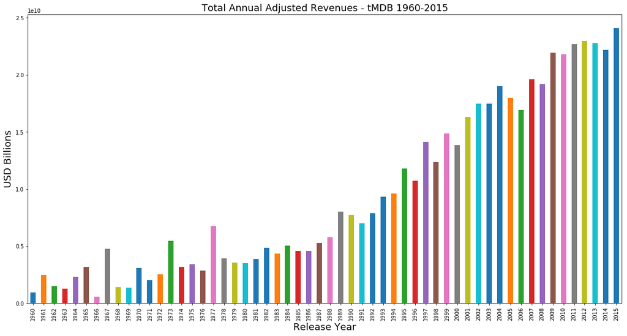

```python
# Showing growth of total adjusted yearly revenues in billions of dollars.
df_adj['revenue_adj'].groupby(df_adj['release_date'].dt.to_period('Y')).sum().plot(kind='bar', title='Total Annual Adjusted Revenues 1960-2015 - TMDb', figsize=(20,10))
plt.title('Total Annual Adjusted Revenues - tMDB 1960-2015', fontsize=18)
plt.xlabel('Release Year', fontsize=18)
plt.ylabel('USD Billions', fontsize=18)
```

> Adjusted revenues have grown exponentially since 1960. However, we can observe a plateau since 2009.

```
Text(0,0.5,'USD Billions')
```

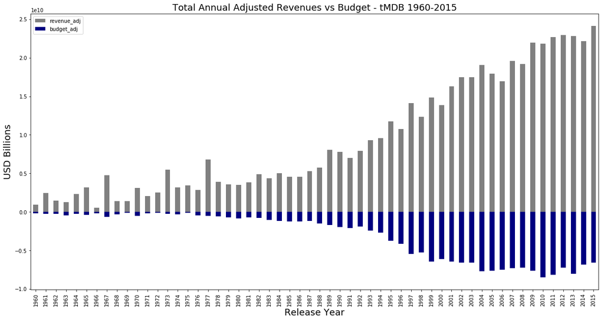

```python
# Showing correlation between growth in adjusted revenues and budgets.
df_adj['budget_adj']=-df_adj['budget_adj'] #negating budget_adj
ax = df_adj[['revenue_adj','budget_adj']].groupby(df_adj['release_date'].dt.to_period('Y')).sum().plot(kind = 'bar', stacked = True,color = ['grey','navy'], figsize=(20,10))
plt.title('Total Annual Adjusted Revenues vs Budget - tMDB 1960-2015', fontsize=18)
plt.xlabel('Release Year', fontsize=18)
plt.ylabel('USD Billions', fontsize=18)
```

> Production budgets have dramatically increased since 1990.

```
Text(0,0.5,'USD Billions')
```

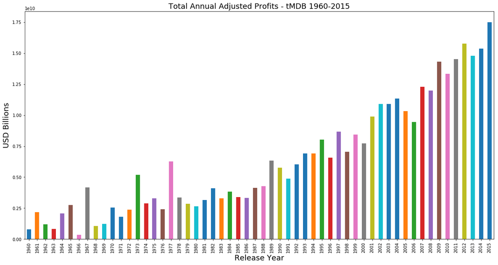

```python
# Measuring profits
df_adj['budget_adj']=-df_adj['budget_adj'] #note: we negate budget_adj column as we negated it in the previous computation
df_adj['profits_adj']=df_adj['revenue_adj']-df_adj['budget_adj']
df_adj['profits_adj'].groupby(df_adj['release_date'].dt.to_period('Y')).sum().plot(kind='bar', figsize=(20,10))
plt.title('Total Annual Adjusted Profits - tMDB 1960-2015', fontsize=18)
plt.xlabel('Release Year', fontsize=18)
plt.ylabel('USD Billions', fontsize=18)
```

> Despite the rise of production budgets and the plateau in revenue growth, profits have dramatically increased since 2001.

### Genres

```
Text(0.5,1,'Genre Distribution - tMDB 1960-2015')
```

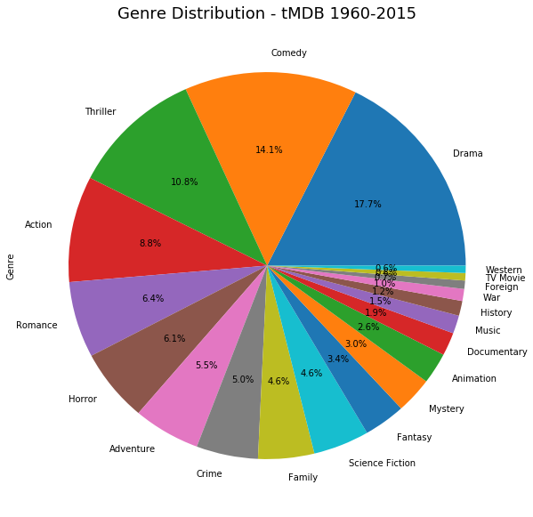

```python
# Creating a pie chart showing distribution of genres overall.
# 4 (four) genres make for 50% of distribution
df.genres.str.split('|', expand=True).stack().value_counts().plot(kind='pie', autopct='%1.1f%%', label='Genre', figsize =(10,10))
plt.title('Genre Distribution - tMDB 1960-2015', fontsize=18)
```

```
Text(0.5,1,'Genre Distribution vs Profits - tMDB 1960-2015')
```

[figure not shown]

```python
# Creating a pie chart showing distribution of genres based on adjusted profits.
# Creating new dataframe for seprate genres columns
genres = (df_adj.genres.str.split('|', expand=True)
            .stack()
            .to_frame(name='genre')
            )

genres.index = genres.index.droplevel(1)

# Joining new genredf to profits_adj of originaldf
genres_profits = (genres.join(df_adj['profits_adj'])
       .groupby('genre')
       .sum()
       .sort_values('profits_adj', ascending = False))

# Droping Foreign column as Pandas pie doesn't accept negative values.
genres_profits.drop(['Foreign'], axis=0, inplace=True)

genres_profits.plot.pie(subplots=True, autopct='%1.1f%%', legend=False, figsize = (10,10))
plt.title('Genre Distribution vs Profits - tMDB 1960-2015', fontsize=18)
```

> The above pie charts show that the way a movie is branded with certain genre(s) does not correlate with its revenues.

> The second pie chart gives us an aggregate picture of the most financially successful genres. However, doing an analysis on a per year basis should shed a brigther light on trends.

```python
# Creating new dataframe to single out genres, profits and release year.
genres_profits_year = genres.join(df_adj[['profits_adj','release_date']])
genres_profits_year['year'] = genres_profits_year['release_date'].dt.year
genres_profits_year.drop('release_date', axis=1, inplace=True)
genres_profits_year
df2 = genres_profits_year.pivot_table(index=['genre'],
                    columns='year',
                    values='profits_adj',
                    fill_value=0,
                    aggfunc='mean')
df2
```

| year genre | 1960 | 1961 | 1962 | 1963 | 1964 | 1965 | 1966 | 1967 | 1968 | 1969 | ... | 2006 | 2007 | 2008 | 2009 | 2010 | 2011 | 2012 | 2013 | 2014 | 2015 |
| --- | --- | --- | --- | --- | --- | --- | --- | --- | --- | --- | --- | --- | --- | --- | --- | --- | --- | --- | --- | --- | --- |
| Action | 1.876605e+08 | 7.732553e+07 | 3.369950e+08 | 2.470658e+08 | 8.534745e+08 | 5.347715e+08 | 3.139664e+07 | 3.314782e+08 | 1.570403e+08 | 4.456682e+08 | ... | 8.487284e+07 | 1.107901e+08 | 9.379915e+07 | 1.595259e+08 | 7.534715e+07 | 1.050914e+08 | 1.688774e+08 | 1.136496e+08 | 1.928579e+08 | 2.435850e+08 |
| Adventure | 2.141847e+07 | 8.563438e+08 | 3.568182e+08 | 2.755465e+08 | 8.534745e+08 | 5.347715e+08 | 4.999882e+07 | 4.510016e+08 | 1.788970e+08 | 2.061740e+08 | ... | 1.140697e+08 | 2.159200e+08 | 8.971788e+07 | 2.511004e+08 | 1.942801e+08 | 2.146707e+08 | 3.130668e+08 | 1.938564e+08 | 2.568943e+08 | 2.641271e+08 |
| Animation | 0.000000e+00 | 1.545635e+09 | 0.000000e+00 | 0.000000e+00 | 0.000000e+00 | 0.000000e+00 | 0.000000e+00 | 1.319404e+09 | 0.000000e+00 | 0.000000e+00 | ... | 1.240658e+08 | 2.588186e+08 | 1.622661e+08 | 2.084874e+08 | 2.980704e+08 | 2.022805e+08 | 2.453425e+08 | 2.676599e+08 | 2.142049e+08 | 3.018189e+08 |
| Comedy | 9.621723e+07 | 4.048283e+08 | 0.000000e+00 | 6.746077e+07 | 2.446851e+08 | 1.685157e+08 | 0.000000e+00 | 2.265753e+08 | 0.000000e+00 | 0.000000e+00 | ... | 6.018581e+07 | 8.234709e+07 | 5.827131e+07 | 7.541893e+07 | 5.899026e+07 | 6.229488e+07 | 7.827360e+07 | 8.753448e+07 | 9.414449e+07 | 9.326924e+07 |
| Crime | 0.000000e+00 | 2.747013e+08 | 8.022893e+07 | 0.000000e+00 | 3.420112e+07 | 0.000000e+00 | 0.000000e+00 | 1.532834e+08 | 2.307033e+08 | 5.724855e+08 | ... | 4.304640e+07 | 2.888815e+07 | 7.451781e+07 | 2.472514e+07 | 2.628337e+07 | 5.009186e+07 | 6.883811e+07 | 5.197655e+07 | 2.722691e+07 | 1.210222e+08 |
| Documentary | 0.000000e+00 | 0.000000e+00 | 0.000000e+00 | 0.000000e+00 | 0.000000e+00 | 0.000000e+00 | 0.000000e+00 | 0.000000e+00 | 0.000000e+00 | 0.000000e+00 | ... | 3.883213e+07 | 2.276753e+07 | 4.253704e+06 | -2.605533e+06 | 1.169729e+06 | 2.559035e+07 | 2.451620e+07 | 0.000000e+00 | 0.000000e+00 | 0.000000e+00 |
| Drama | 2.486977e+08 | 1.046851e+08 | 1.493300e+08 | 4.897497e+07 | 1.344628e+08 | 5.645708e+08 | 1.150013e+08 | 2.734809e+08 | 9.503850e+07 | 4.086502e+08 | ... | 2.990925e+07 | 4.246108e+07 | 4.981835e+07 | 4.302744e+07 | 4.101538e+07 | 2.704696e+07 | 7.748983e+07 | 3.795012e+07 | 4.495271e+07 | 4.761897e+07 |
| Family | 0.000000e+00 | 7.764651e+08 | 0.000000e+00 | 0.000000e+00 | 5.317439e+08 | 1.072786e+09 | 0.000000e+00 | 6.302866e+08 | 4.262895e+07 | 0.000000e+00 | ... | 8.667322e+07 | 2.143580e+08 | 1.249560e+08 | 1.632129e+08 | 2.504236e+08 | 1.896357e+08 | 2.292591e+08 | 2.135119e+08 | 1.626407e+08 | 2.460353e+08 |
| Fantasy | 0.000000e+00 | 0.000000e+00 | 0.000000e+00 | 0.000000e+00 | 6.768230e+08 | 0.000000e+00 | 0.000000e+00 | -5.883087e+07 | 0.000000e+00 | 0.000000e+00 | ... | 1.164417e+08 | 2.385549e+08 | 1.299335e+08 | 2.594833e+08 | 1.763002e+08 | 2.228146e+08 | 2.584241e+08 | 1.841196e+08 | 2.679120e+08 | 2.021103e+08 |
| Foreign | 0.000000e+00 | 0.000000e+00 | 0.000000e+00 | 0.000000e+00 | 0.000000e+00 | 0.000000e+00 | 0.000000e+00 | 0.000000e+00 | 0.000000e+00 | 0.000000e+00 | ... | 0.000000e+00 | 6.188891e+05 | 2.644832e+07 | 0.000000e+00 | -3.364539e+06 | 0.000000e+00 | 0.000000e+00 | 0.000000e+00 | 0.000000e+00 | 0.000000e+00 |
| History | 3.539024e+08 | 5.106403e+07 | 3.964647e+08 | 4.897497e+07 | 0.000000e+00 | -5.536451e+07 | 0.000000e+00 | 0.000000e+00 | 8.337722e+07 | 5.724855e+08 | ... | 1.557169e+07 | 2.739700e+07 | 3.193365e+07 | 3.106348e+07 | 9.072747e+07 | 4.936206e+07 | 4.045250e+07 | 3.875779e+07 | 7.809914e+07 | 1.260662e+07 |
| Horror | 2.299854e+08 | 1.313075e+07 | 0.000000e+00 | 6.339472e+07 | 0.000000e+00 | 0.000000e+00 | 0.000000e+00 | 0.000000e+00 | 1.892940e+08 | 0.000000e+00 | ... | 4.171708e+07 | 5.053103e+07 | 3.021571e+07 | 3.378094e+07 | 4.274173e+07 | 3.099436e+07 | 4.082429e+07 | 6.885928e+07 | 3.713728e+07 | 3.829838e+07 |
| Music | 0.000000e+00 | 2.747013e+08 | 0.000000e+00 | 0.000000e+00 | 3.556689e+08 | 1.072786e+09 | 0.000000e+00 | 1.176617e+08 | 4.262895e+07 | 0.000000e+00 | ... | 1.034828e+08 | 6.837170e+07 | 3.680303e+07 | 1.087938e+08 | -7.004189e+06 | 8.771997e+07 | 8.173418e+07 | 2.812041e+05 | 5.727896e+07 | 5.551058e+07 |
| Mystery | 0.000000e+00 | 0.000000e+00 | 0.000000e+00 | 6.746077e+07 | 3.420112e+07 | 0.000000e+00 | 6.718015e+07 | 1.659029e+08 | 2.142026e+08 | 0.000000e+00 | ... | 6.041517e+07 | 1.160529e+08 | 3.414998e+07 | 3.441935e+07 | 9.409800e+07 | 8.103858e+07 | 6.411428e+07 | 2.250162e+07 | 7.986984e+07 | 2.491384e+07 |
| Romance | 9.621723e+07 | 5.106403e+07 | 0.000000e+00 | 1.285534e+08 | 2.249686e+08 | 8.745385e+08 | 5.374412e+07 | 3.228569e+08 | -8.484039e+05 | 0.000000e+00 | ... | 4.073041e+07 | 4.534377e+07 | 8.790148e+07 | 6.085790e+07 | 6.582084e+07 | 5.550608e+07 | 7.480062e+07 | 2.252902e+07 | 5.881889e+07 | 6.686963e+07 |
| Science Fiction | 0.000000e+00 | 0.000000e+00 | 0.000000e+00 | 0.000000e+00 | 0.000000e+00 | 0.000000e+00 | 4.625353e+07 | 0.000000e+00 | 1.508218e+08 | 0.000000e+00 | ... | 2.107266e+07 | 9.064440e+07 | 4.507210e+07 | 1.691419e+08 | 1.210529e+08 | 1.244743e+08 | 1.422221e+08 | 2.279195e+08 | 2.142622e+08 | 3.027898e+08 |
| TV Movie | 0.000000e+00 | 0.000000e+00 | 0.000000e+00 | 0.000000e+00 | 0.000000e+00 | 0.000000e+00 | 0.000000e+00 | 0.000000e+00 | 0.000000e+00 | 0.000000e+00 | ... | 0.000000e+00 | 0.000000e+00 | 0.000000e+00 | 0.000000e+00 | 0.000000e+00 | 0.000000e+00 | 0.000000e+00 | 0.000000e+00 | 0.000000e+00 | 0.000000e+00 |
| Thriller | 2.299854e+08 | 0.000000e+00 | 4.216943e+08 | 2.061846e+08 | 4.438378e+08 | 9.010273e+08 | 6.718015e+07 | 2.929881e+08 | 2.307033e+08 | 4.456682e+08 | ... | 5.901506e+07 | 5.018582e+07 | 6.898553e+07 | 4.471629e+07 | 4.130180e+07 | 4.911951e+07 | 6.510802e+07 | 7.331822e+07 | 8.555853e+07 | 1.119523e+08 |
| War | 0.000000e+00 | 1.670523e+08 | 3.964647e+08 | 7.120179e+06 | 5.371316e+07 | 6.762907e+08 | 5.374412e+07 | 1.326963e+08 | 5.422654e+07 | 0.000000e+00 | ... | 3.879271e+06 | 1.140839e+08 | 1.931840e+07 | 1.054274e+08 | 8.997710e+07 | 1.660929e+07 | 4.535156e+07 | 6.899741e+07 | 1.423129e+08 | 8.811818e+07 |
| Western | 2.141847e+07 | -1.240126e+07 | 1.434481e+08 | 0.000000e+00 | 0.000000e+00 | 0.000000e+00 | 9.049166e+06 | 0.000000e+00 | 3.134482e+07 | 2.695826e+08 | ... | -1.817604e+07 | -1.430201e+05 | 2.140970e+05 | 0.000000e+00 | -7.869883e+07 | 5.939838e+07 | 3.090166e+08 | -8.082833e+07 | -1.249922e+07 | 2.344668e+08 |

20 rows × 56 columns

```
Text(0.5,1,'Genre Distribution by Profits and Year - tMDB 1960-2015')
```

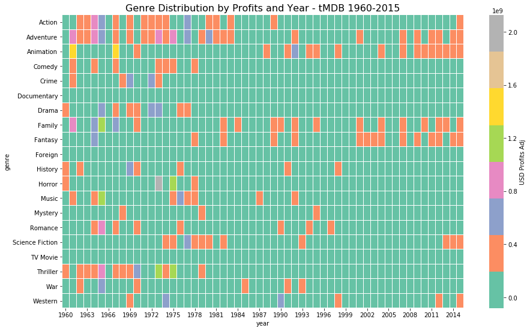

```python
fig, ax = plt.subplots(figsize=(15,9))
cmap = sns.color_palette("Set2")
sns.heatmap(df2.iloc[:,0:56], xticklabels=3, cmap=cmap, linewidths=0.01, cbar_kws={'label': 'USD Profits Adj'})
plt.title('Genre Distribution by Profits and Year - tMDB 1960-2015', fontsize=16)
```

> The most striking result is the difference between **Adventure** and **Action**. While these two genres were showing equal overall profits in the pie chart, the heatmap shows that **Adventure** to be more consistently overperforming in recent years.

> The heatmap also highlights that some genres are trending upwards in recent years. For instance **Fantasy** and **Family** are equally distributed compared to **Adventure** and **Action** since 2001 despite the former two genres being half in proportion to the latter in the pie chart.

> Finally, **Animation** shows in recent years a distribution in the heatmap which equals that of the other top genres both in the pie chart and the heatmap.

### Runtime / Duration Across the Years

```python
df['runtime'].describe()
```

```
count    10865.000000
mean       102.071790
std         31.382701
min          0.000000
25%         90.000000
50%         99.000000
75%        111.000000
max        900.000000
Name: runtime, dtype: float64
```

> Below is a heatmap showing how duration has evolved per genre per year. Based on the runtime statistics previously discussed, we will limit the runtime data to a max of 130 minutes.

```
Text(0.5,1,'Change in Runtime by Genre and Year - tMDB 1960-2015')
```

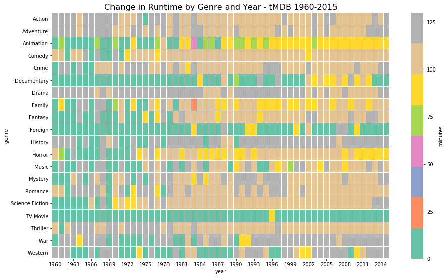

```python
genres_runtime = genres.join(df[['runtime','release_date']])
genres_runtime['year'] = genres_runtime['release_date'].dt.year
genres_runtime.drop('release_date', axis=1, inplace=True)
genres_runtime
df3 = genres_runtime.pivot_table(index=['genre'],
                    columns='year',
                    values='runtime',
                    fill_value=0,
                    aggfunc='mean')

fig, ax = plt.subplots(figsize=(15,9))
cmap = sns.color_palette("Set2")
sns.heatmap(df3.iloc[:,0:56], xticklabels=3,cmap=cmap, linewidths=0.01, vmin=0, vmax=130, cbar_kws={'label': 'minutes'})
plt.title('Change in Runtime by Genre and Year - tMDB 1960-2015', fontsize=16)
```

> Certain genres have consistently had their runtime shorter than others, this is clearly showing for **Animation**, **Family** and **Horror**.

> **War** and **History** are consistently longer than any other genres.

> Up until the end of the 1970s, many movies could run over **110 minutes** (grey cells). The trend shows that most genres are now below or around the 110 minutes mark.

### Release Timing

```
Text(0.5,1,'Release Months by Profitability - tMDB 1960-2015')
```

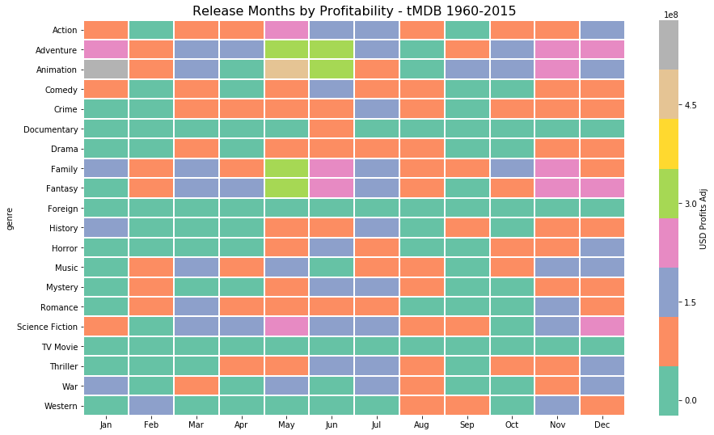

```python
genres_profits_month = genres.join(df_adj[['profits_adj','release_date']])
genres_profits_month['month'] = genres_profits_month['release_date'].dt.month
genres_profits_month.drop('release_date', axis=1, inplace=True)
genres_profits_month
df4 = genres_profits_month.pivot_table(index=['genre'],
                    columns='month',
                    values='profits_adj',
                    fill_value=0,
                    aggfunc='mean')

df4.columns = ['Jan', 'Feb','Mar','Apr','May','Jun','Jul','Aug','Sep','Oct','Nov','Dec']

fig, ax = plt.subplots(figsize=(15,9))
cmap = sns.color_palette("Set2")
sns.heatmap(df4.iloc[:,0:56], xticklabels=True, cmap=cmap, linewidths=1, cbar_kws={'label': 'USD Profits Adj'})
plt.title('Release Months by Profitability - tMDB 1960-2015', fontsize=16)
```

> The most significant months are **May** and **June**.

> In the lower bracket, pink cells show that the months of **November** and **December** are also performing.

## Conclusions

### Severe Limitations With Zero Values

> The 'budget_adj' and 'revenue_adj' columns are overwhelmingly populated (>50%) with zero values, making quantitative analysis a biased exercise.

### Possible Conclusions for Non Zero Values

> Movies are good business: the trend in profits is updward despite plateauing revenues. However this comes at a cost with a rise in production budgets.

> While movies are branded across several genres, the most successful movies are those with a taste of **Action**, **Adventure**, **Drama** and **Comedy**. **Fantasy** and **Animation** are also rising genres in recent years.

> The most successful movies are released during the months of **May** and **June**, followed by a second bracket for **November** and **December**.